# **Chapter 05 迴圈與迭代 (Loops and Iteration)**

## **不確定迴圈 (Indefinite Loops)**

### 重複性步驟 (Repeated Steps)

- 迴圈 (重複性步驟) 有一個迭代變數，在每次迴圈執行時都會改變。迭代變數通常都是數字數列 (e.g. 1,2,3,4,5)

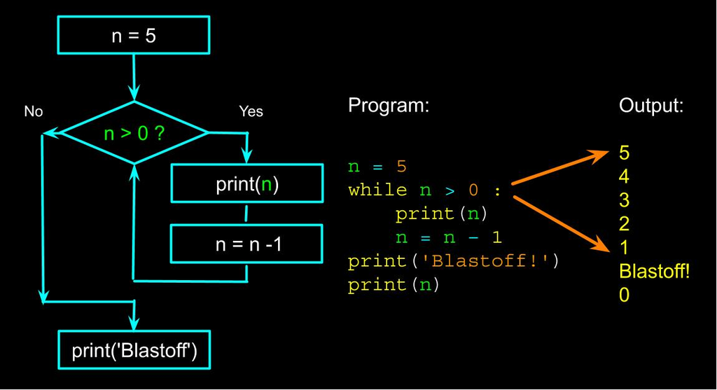

```python
# n是迭代變數
n = 5

# 只要n > 0就繼續執行
while n > 0:
    print(n)
    # 每次迴圈迭代變數都減1
    n = n - 1

# 迴圈執行結束
print('Blastoff!')
print(n)
```

```
5
4
3
2
1
Blastoff!
0
```

### 無窮迴圈 (An Infinite Loop)

- 這個迴圈出了什麼事情？

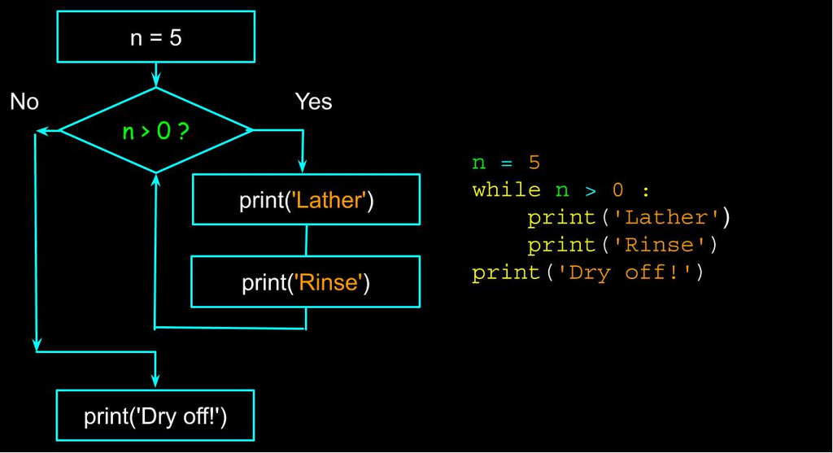

```python
n = 5
while n > 0:
    print('Lather')
    print('Rinse')
print('Dry off!')
```

### 另一個迴圈

- 這個迴圈在做什麼？

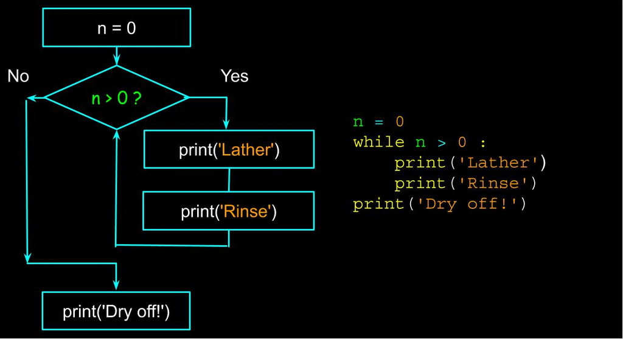

```python
n = 0
while n > 0:
    print('Lather')
    print('Rinse')
print('Dry off!')
```

```
Dry off!
```

### 跳出迴圈 (Breaking out of a Loop)

- **break**可以終止目前的迴圈並且立刻繼續執行迴圈結束後的程式
- 這就像是個回圈測試，可以在迴圈內部任何地方執行

```python
while True:
    line = input('> ')
    # 輸入done程式就終止
    if line == 'done':
        break
    print(line)
print('Done')
```

```
> hello there
hello there
> finished
finished
> done
Done
```

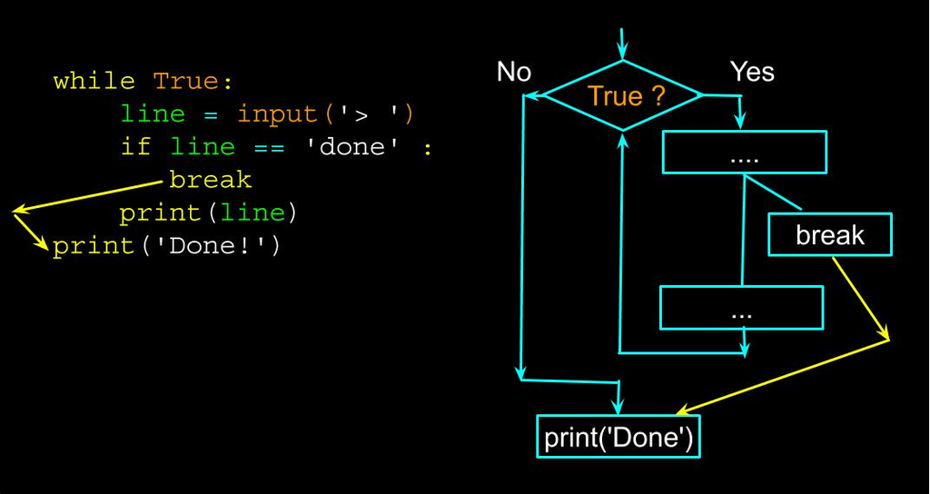

### 使用Continue結束迭代

- **continue**可以終結目前的迭代，並且跳躍至迴圈最上方再進行下一次的迭代

```python
while True:
    line = input('> ')
    if line[0] == '#':
        continue
    if line == 'done':
        break
    print(line)
print('Done!')
```

```
> hello there
hello there
> #don't print this
> print this!
print this!
> done
Done!
```

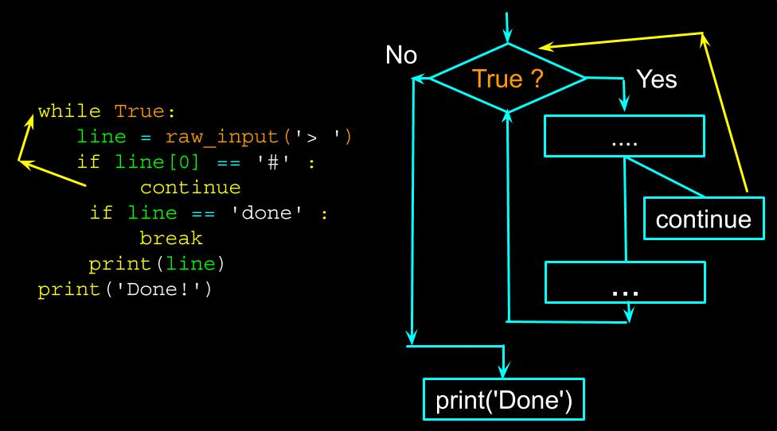

### 不確定迴圈 (Indefinite Loops)

- while迴圈也稱為不確定迴圈，因為它會持續執行直到某個特定的邏輯條件成為False為止
- 到目前為止，我們已經很容易地檢查到迴圈是否會終止或是否為「無限迴圈」
- 有時候會有一點點難確定一個迴圈是否會停止

### 練習While迴圈

- While迴圈當迭代變數小於6時，就繼續執行
- 每次執行時，印出當前迭代變數的3次方的值在畫面上

## **確定迴圈 (Definite Loops)**

- 通常，我們在文件中有很多行文字-實際上是一組有限的東西
- 我們可以使用Python寫一個迴圈來迭代其中每一行
- 這種迴圈就稱為「確定迴圈」，因為他們有很明確的執行次數
- 我們說「確定迴圈」就是迭代一組有限資料的每個項目

### 簡單的確定迴圈

```
for i in [5, 4, 3, 2, 1] :
    print(i)
print('Blastoff!')
```

```python
for i in [5, 4, 3, 2, 1]:
    print(i)
print('Blastoff')
```

```
5
4
3
2
1
Blastoff
```

### 簡單的確定迴圈

- 確定迴圈 (for 迴圈)有個明確的迭代變數，在每次迴圈執行迭代時都會改變。這個迭代變數會在一個序列或是一組資料中移動

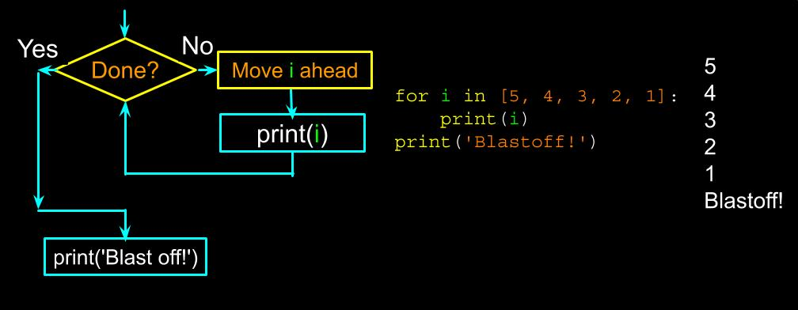

### 看向「in」這個語法

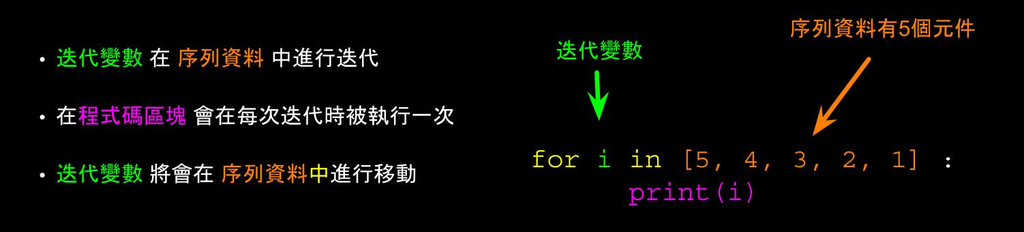

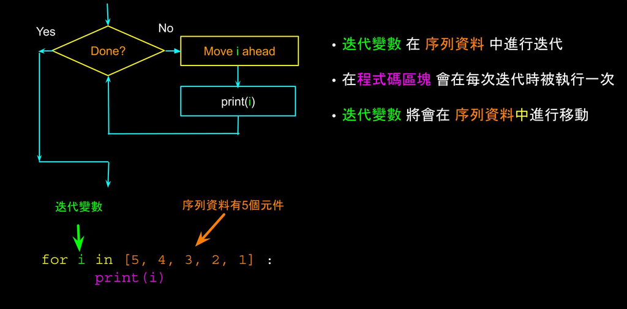

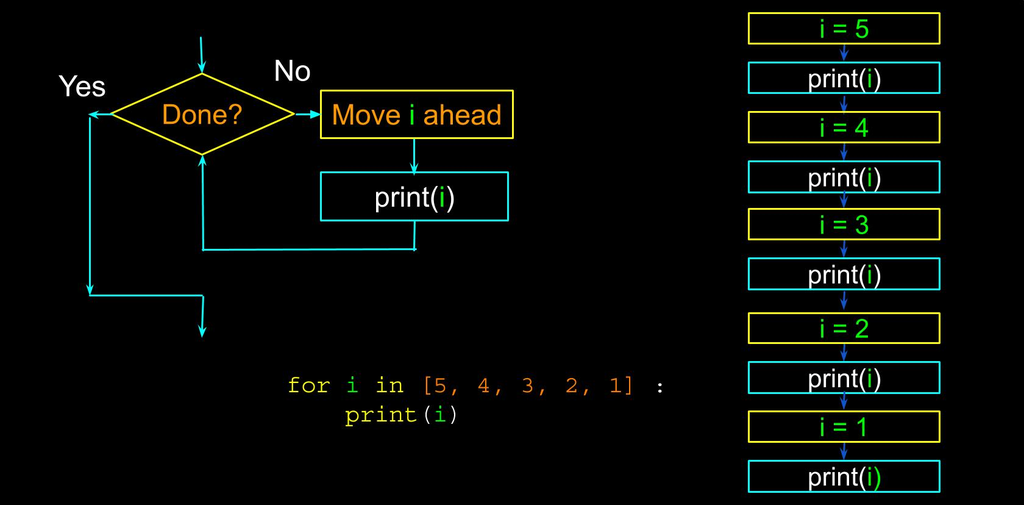

### 針對字串陣列執行的確定迴圈

```python
friends = ['Joseph', 'Glenn', 'Sally']
for friend in friends:
    print('Happy New Year:', friend)
print('Done!')
```

```
Happy New Year: Joseph
Happy New Year: Glenn
Happy New Year: Sally
Done!
```

### 練習For迴圈

- For迴圈執行序列資料0~5
- 每次執行時，印出當前迭代變數的3次方的值在畫面上

## **迴圈的慣用法：我們通常使用迴圈做什麼？**

### 建立「聰明的」迴圈

- 訣竅是，當你寫一次迭代的內容時，就可以知道有關整個迴圈在做的事情

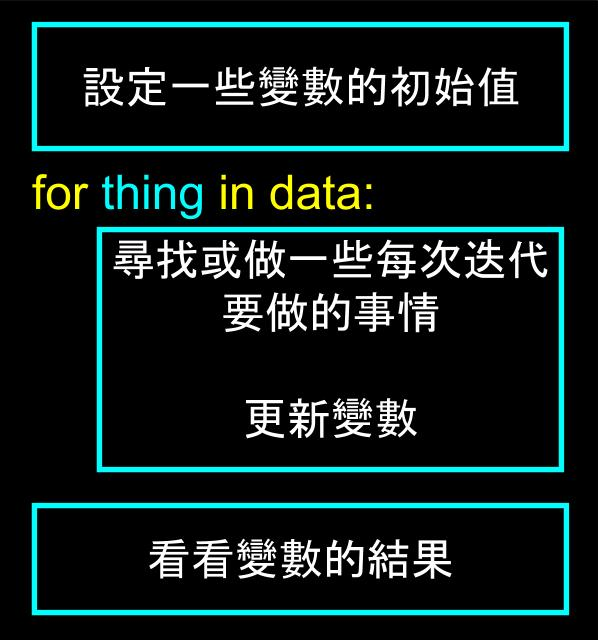

### 對一組資料(Set)進行迴圈

```python
print('迴圈之前')
for thing in [9, 41, 12, 3, 74, 15]:
    print(thing)
print('迴圈之後')
```

[output not shown]

### 找出最大的數值

- 9, 41, 12, 3, 74, 15
- 我們創造一個變數，該變數負責儲存目前的最大值。在迴圈的迭代中，如果發現目前的數字更大，這就是目前為止看到的最大數字，就更新變數

```python
largest_so_far = -1
print('迴圈之前', largest_so_far)
for the_num in [9, 41, 12, 3, 74, 15]:
    if the_num > largest_so_far:
        largest_so_far = the_num
    print(largest_so_far, the_num)
print('迴圈之後', largest_so_far)
```

```
迴圈之前 -1
9 9
41 41
41 12
41 3
74 74
74 15
迴圈之後 74
```

## **更多迴圈的模式(pattern)**

### 計算迴圈迭代了幾次

- 為了計算迴圈的迭代進行了幾次，我們建立一個叫做counter的變數，由0開始。每次迭代都加1，來計算迴圈迭代的總次數

```python
zork = 0
print('迴圈之前', zork)
for thing in [9, 41, 12, 3, 74, 15]:
    zork = zork + 1
    print(zork, thing)
print('迴圈之後', zork)
```

```
迴圈之前 0
1 9
2 41
3 12
4 3
5 74
6 15
迴圈之後 6
```

### 計算加總結果

- 為了累加一個迴圈迭代中遇到的值，我們設定一個從0開始的sum變數，並且每次迴圈迭代時都加到sum中

```python
zork = 0
print('迴圈之前', zork)
for thing in [9, 41, 12, 3, 74, 15]:
    zork = zork + thing
    print(zork, thing)
print('迴圈之後', zork)
```

```
迴圈之前 0
9 9
50 41
62 12
65 3
139 74
154 15
迴圈之後 154
```

### 找出平均數

- 平均數就是結合之前的「計算迴圈迭代了幾次」與「計算加總結果」，迴圈結束後再進行除法

```python
count = 0
sum = 0
print('迴圈之前', count, sum)
for thing in [9, 41, 12, 3, 74, 15]:
    count = count + 1
    sum = sum + thing
    print(count, sum, thing)
print('迴圈之後', count, sum, sum / count)
```

```
迴圈之前 0 0
1 9 9
2 50 41
3 62 12
4 65 3
5 139 74
6 154 15
迴圈之後 6 154 25.666666666666668
```

### 過濾資料

- 我們在迴圈中使用if語句來過濾或查找我們要的內容

```python
print('迴圈之前')
for value in [9, 31, 12, 3, 74, 15]:
    if value > 20:
        print('Large number', value)
print('迴圈之後')
```

```
迴圈之前
Large number 31
Large number 74
迴圈之後
```

### 使用布林(Boolean)變數找尋資料

- 如果想在資料集中搜索特定的值，則使用一個變數，預設值為False，在迴圈迭代時以if語句做檢查，找到所需內容後立即設置變數為True

```python
found = False
print('迴圈之前', found)
for value in [9, 31, 12, 3, 74, 15]:
    if value == 3:
        found = True
    print(found, value)
print('迴圈之後', found)
```

```
迴圈之前 False
False 9
False 31
False 12
True 3
True 74
True 15
迴圈之後 True
```

```python
found = False
print('迴圈之前', found)
for value in [9, 31, 12, 3, 74, 15]:
    if value == 3:
        found = True
        break
    print(found, value)
print('迴圈之後', found)
```

```
迴圈之前 False
False 9
False 31
False 12
迴圈之後 True
```

### 如何找尋最小的數值？

- 我們如何改變找最大值的程式碼，改成找最小值？

```python
largest_so_far = -1
print('迴圈之前', largest_so_far)
for the_num in [9, 31, 12, 3, 74, 15]:
    if the_num > largest_so_far:
        largest_so_far = the_num
    print(largest_so_far, the_num)
print('迴圈之後', largest_so_far)
```

```
迴圈之前 -1
9 9
31 31
31 12
31 3
74 74
74 15
迴圈之後 74
```

### 如何找尋最小的數值？(1)

- 我們將變數命名切換為smallest_so_far，然後將>切換為<

```python
smallest_so_far = -1
print('迴圈之前', smallest_so_far)
for the_num in [9, 31, 12, 3, 74, 15]:
    if the_num < smallest_so_far:
        smallest_so_far = the_num
    print(smallest_so_far, the_num)

print('迴圈之後', smallest_so_far)
```

```
迴圈之前 -1
-1 9
-1 31
-1 12
-1 3
-1 74
-1 15
迴圈之後 -1
```

### 如何找尋最小的數值？(2)

- 我們依然保持有變數紀錄最小的數值，但是迴圈開始時，該變數的初始值是**None**，表示沒有儲存過任何數值
- 比對數值是否為None的方式是使用**is**

```python
smallest = None
print('迴圈之前')
for value in [9, 31, 12, 3, 74, 15]:
    # 使用is作為比較
    if smallest is None:
        smallest = value
    if value < smallest:
        smallest = value
    print(smallest, value)

print('迴圈之後', smallest)
```

```
迴圈之前
9 9
9 31
9 12
3 3
3 74
3 15
迴圈之後 3
```

### **is**和**is not**比較運算

- 在比較判斷式中，is和is not是一種運算比較的運算子(operator)
- 他與「完全等於」相似
- 他與「==」相似
- 平時能使用==時，不要使用is
- is及is not是用於比較None, True與False這三種數值型態

### 練習

- 下列數組，找出最大值、最小值、總和以及平均數
- 89,87,55,44,17,80,85,52,29,60

## **總結複習**

- While迴圈 (不確定迴圈 Indefinite Loop)
- For迴圈 (確定迴圈 Definite Loop)
- 迭代變數 (Iteration Variable)
- 使用break
- 使用continue
- 迴圈慣用法
- 找尋最大和最小值
- None型態

## **作業**

- 撰寫一個程式，會不停請用戶輸入數字
- 畫面出現提示「請輸入數字，輸入done結束程式:」，等待用戶輸入
- 直到用戶輸入「done」，程式才會停止
- 程式停止前，要印出用戶輸入過程中，輸入的最大值和最小值
- 當用戶輸入非數字的數值時，程式不能當機，並且跳出文字「輸入的內容不是數字唷」來提醒用戶 (使用try - except)
- 輸入7, 2, bob, 10, 4來驗證程式是否正確，結果應該如下：

  ```
  請輸入數字，輸入done結束程式: 7
  請輸入數字，輸入done結束程式: 2
  請輸入數字，輸入done結束程式: bob
  輸入的內容不是數字唷
  請輸入數字，輸入done結束程式: 10
  請輸入數字，輸入done結束程式: 4
  請輸入數字，輸入done結束程式: done
  最大值 10
  最小值 2
  ```

# Acknowledgements / Contributions

Python For Everyone

- These slides are Copyright 2010- Charles R. Severance (www.dr-chuck.com) of the University of Michigan School of Information and made available under a Creative Commons Attribution 4.0 License. Please maintain this last slide in all copies of the document to comply with the attribution requirements of the license. If you make a change, feel free to add your name and organization to the list of contributors on this page as you republish the materials.
- Initial Development: Charles Severance, University of Michigan School of Information